# Hogares feminizados y presupuestos familiares

## **Análisis**

Para realizar el análisis partiremos con las siguientes hipótesis: 1. H0: No hay una relación significativa entre el ingreso y gasto del hogar por género de la persona 2. H1: Existe relación significativa entre el ingreso y el gasto del hogar por género de la persona 3. H2: Existe relación entre gasto e ingreso por género y vivir en una capital regional que no sea Santiago 4. H3: Existe relación entre gasto e ingreso por género y por la cantidad de personas del hogar y sus edades 5. H4: Existe relación entre gasto e ingreso por género y el tipo y tenencia de vivienda 6. H5: Existe relación entre gasto e ingreso por género y nivel educacional

#6. Modelo 1 de regresión líneal

```r
modelo1<- svyglm(gastos ~ sexo_cat + ingreso_liquido,
                         family = gaussian(link = "identity"),
                         design = presupuestos_familiares)
```

##6.1 Tabla modelo 1

```r
sjPlot::tab_model(modelo1,
                  show.ci=FALSE,
                  title = "EPF por sexo",
                  encoding = "UTF-8",
                  p.val = "wald",
                  file = "output/figures/tab_modelo1.doc")
```

EPF por sexo

|  | Gasto total por hogar imputado por hot-deck (sin arriendo imputado) |  |
| --- | --- | --- |
| Predictors | Estimates | p |
| (Intercept) | 514188.79 | **<0.001** |
| sexo_cat: Hombre | -12474.08 | 0.191 |
| Ingreso disponible del hogar imputado por hot-deck (sin arriendo imputado) | 0.56 | **<0.001** |
| Observations | 48308 |  |
| R<sup>2</sup> / R<sup>2</sup> adjusted | 0.537 / -89.898 |  |

En el **modelo 1** se puede observar que el R cuadrado presentado es alto, por lo que el modelo se ajusta bastante a los datos. En la misma línea, la variable ingreso es significativa al 99,9%, sin embargo, la categoría “hombre” no lo es, por lo que no sería estadísticamente significativo. Con ello podemos **rechazar la hipótesis alternativa y aceptar la nula**, es decir, no existe una relación estadísticamente significativa entre el ingreso y gasto por género. Cabe mencionar que la dirección de “hombre” es negativa, por lo que se constituye como una relación inversamente proporcional.

#7. Modelo 2 regresión líneal múltiple

```r
modelo2<- svyglm(gastos ~ sexo_cat + ingreso_liquido + zona_cat,
                         family = gaussian(link = "identity"),
                         design = presupuestos_familiares)
```

##7.1 Gráfico modelo2

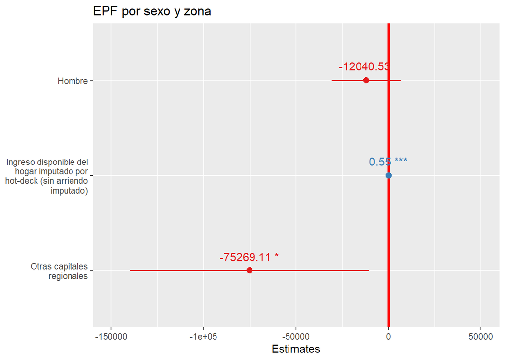

```r
sjPlot::plot_model(modelo2,
                   ci.lvl = c(0.95),
                   title = "EPF por sexo y zona",
                   show.p = T,
                   show.values =  T,
                   vline.color = "red")
```

#8. Modelo 3 regresión lineal múltiple

```r
modelo3<- svyglm(gastos ~ sexo_cat + ingreso_liquido + NPERSONAS + edad_tramos,
                         family = gaussian(link = "identity"),
                         design = presupuestos_familiares)
```

##8.1 Tabla modelo 3

```r
sjPlot::tab_model(modelo3,
                  show.ci=FALSE,
                  title = "EPF por numero de personas en el hogar y sus edades",
                  encoding = "UTF-8",
                  p.val = "wald",
                  file = "output/figures/tab_modelo3.doc")
```

EPF por numero de personas en el hogar y sus edades

|  | Gasto total por hogar imputado por hot-deck (sin arriendo imputado) |  |
| --- | --- | --- |
| Predictors | Estimates | p |
| (Intercept) | 233810.04 | **<0.001** |
| sexo_cat: Hombre | -19257.92 | **0.046** |
| Ingreso disponible del hogar imputado por hot-deck (sin arriendo imputado) | 0.55 | **<0.001** |
| NÃºmero de personas en el hogar | 39753.34 | **<0.001** |
| edad_tramos: Adulto | 145936.52 | **<0.001** |
| edad_tramos: Joven | 143141.02 | **<0.001** |
| Observations | 47873 |  |
| R<sup>2</sup> / R<sup>2</sup> adjusted | 0.543 / -89.047 |  |

#9. Modelo 4 regresión lineal múltiple

```r
modelo4<- svyglm(gastos ~ sexo_cat + ingreso_liquido + vivienda_tipo + vivienda_tenencia,
                         family = gaussian(link = "identity"),
                         design = presupuestos_familiares)
```

##9.1 Gráfico modelo 4

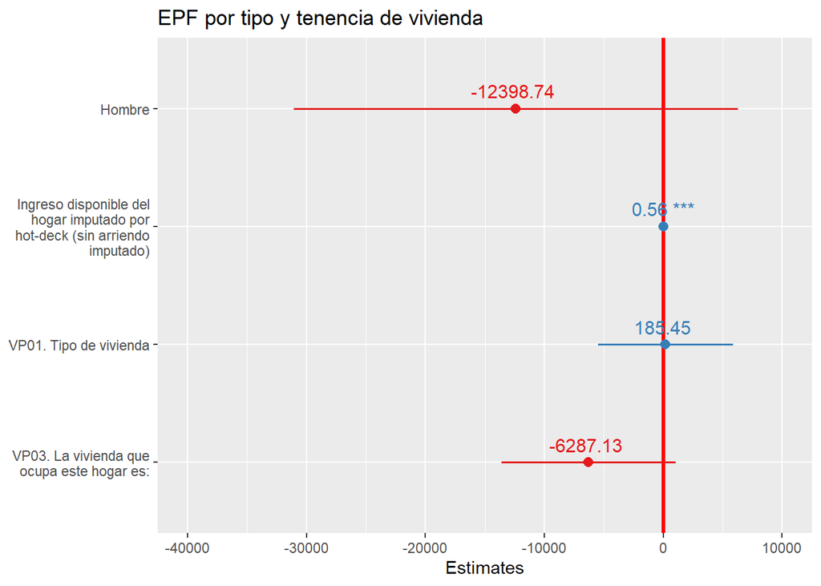

```r
sjPlot::plot_model(modelo4,
                   ci.lvl = c(0.95),
                   title = "EPF por tipo y tenencia de vivienda",
                   show.p = T,
                   show.values =  T,
                   vline.color = "red")
```

#10. Modelo 5 regresión lineal múltiple

```r
modelo5<- svyglm(gastos ~ sexo_cat + ingreso_liquido + N_educ,
                         family = gaussian(link = "identity"),
                         design = presupuestos_familiares)
```

```r
sjPlot::tab_model(modelo5,
                  show.ci=FALSE,
                  title = "EPF por nivel educacional",
                  encoding = "UTF-8",
                  p.val = "wald",
                  file = "output/figures/tab_modelo5.doc")
```

EPF por nivel educacional

|  | Gasto total por hogar imputado por hot-deck (sin arriendo imputado) |  |
| --- | --- | --- |
| Predictors | Estimates | p |
| (Intercept) | 329027.30 | **<0.001** |
| sexo_cat: Hombre | -13196.14 | 0.152 |
| Ingreso disponible del hogar imputado por hot-deck (sin arriendo imputado) | 0.54 | **<0.001** |
| ED03. Nivel mÃ¡s alto alcanzado | 51736.38 | **<0.001** |
| Observations | 48210 |  |
| R<sup>2</sup> / R<sup>2</sup> adjusted | 0.543 / -88.860 |  |

Para el **modelo 5**, el nivel educacional si **es significativo** al 99,9%, mientras el R cuadrado es de 0,54 por lo que explica una asociación importante entre las variables. De igual forma el nivel educacional tiene una dirección positiva, por lo que es directamente proporcional.

## **Referencias**

- Centro Latinoamericano y Caribeño de Demografía (CELADE). (2007). Notas de Población (84.a ed.). Comisión Económica para América Latina y el Caribe. https://repositorio.cepal.org/bitstream/handle/11362/12817/np84131148_es.pdf?sequence=1&isAllowed=y

-Base de Personas VIII (Año). Encuesta de Presupuestos Familiares. Recuperado de nombre base de datos del Instituto Nacional de Estadísticas.